# mtcars Dataset Analysis

### Chapter 2. Bivariate analysis

In this chapter I analyse the behavior of target variable (mpg) conditional on a set of explanatory variables.

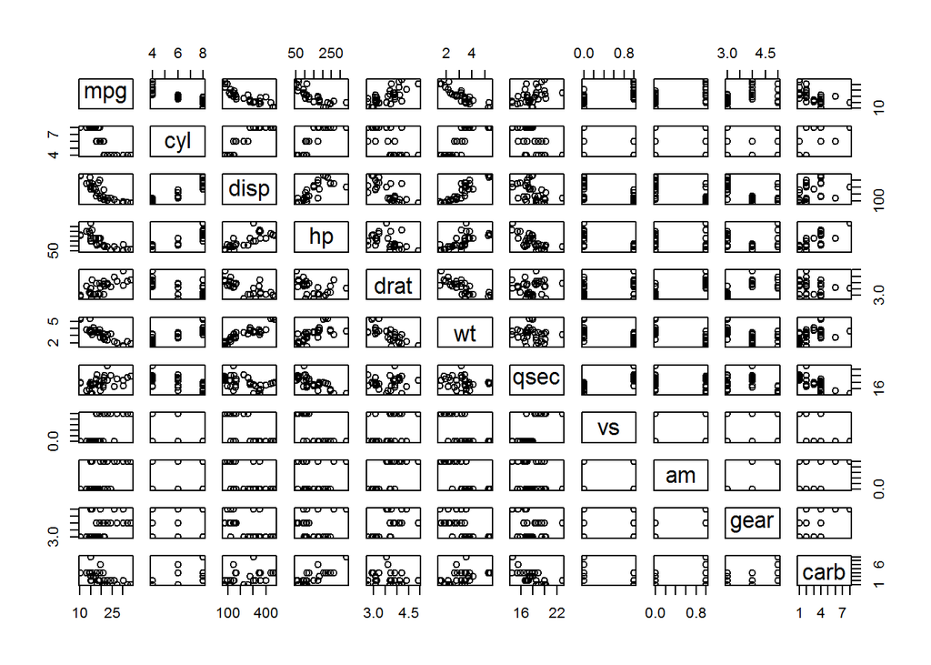

```r
#### generate subset: automatic and manual cars ####
cars_auto = subset(mtcars, am == 0)
cars_manu = subset(mtcars, am == 1)

#### Visual inspection of all covariates ####
pairs(mtcars)
```

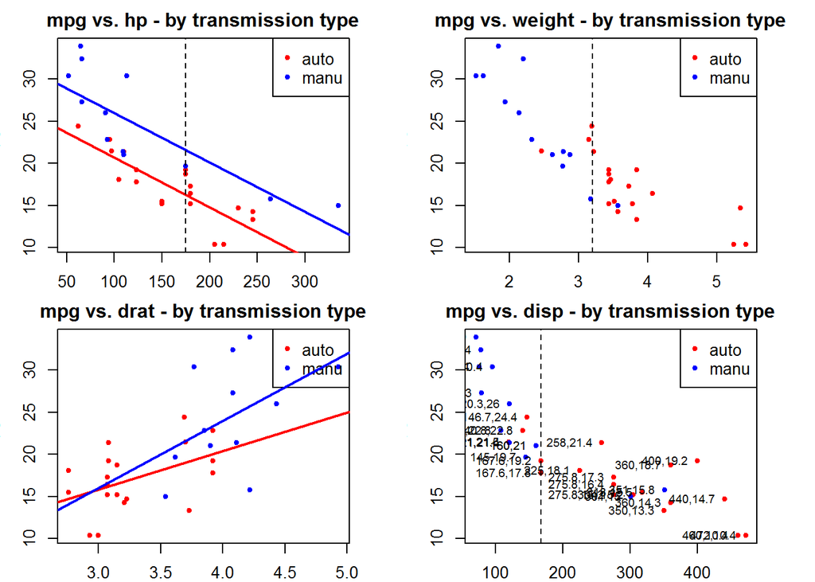

```r
#### 4 bivariate analysis: hp / wt / drat / disp ####
par(mfrow = c(2, 2), mar = c(2, 3, 2, 3))

# plot1
with(mtcars, plot(hp, mpg, type = "n", main = "mpg vs. hp - by transmission type")) # no data
with(cars_auto, points(hp, mpg, col = "red", pch = 20))
with(cars_manu, points(hp, mpg, col = "blue", pch = 20))
legend("topright", pch = 20, col = c("red", "blue"), legend = c("auto", "manu")) # add legend
model1_auto = lm(mpg ~ hp, data = cars_auto)
model1_manu = lm(mpg ~ hp, data = cars_manu)
abline(model1_auto, col = "red", lwd = 2)
abline(model1_manu, col = "blue", lwd = 2)
abline(v = 175, lty = 2)

# plot2
with(mtcars, plot(wt, mpg, type = "n", main = "mpg vs. weight - by transmission type")) # no data
with(cars_auto, points(wt, mpg, col = "red", pch = 20))
with(cars_manu, points(wt, mpg, col = "blue", pch = 20))
legend("topright", pch = 20, col = c("red", "blue"), legend = c("auto", "manu")) # add legend
abline(v = 3.2, lty = 2)

# plot 3
with(mtcars, plot(drat, mpg, type = "n", main = "mpg vs. drat - by transmission type")) # no data
with(cars_auto, points(drat, mpg, col = "red", pch = 20))
with(cars_manu, points(drat, mpg, col = "blue", pch = 20))
legend("topright", pch = 20, col = c("red", "blue"), legend = c("auto", "manu")) # add legend
model2_auto = lm(mpg ~ drat, data = cars_auto)
model2_manu = lm(mpg ~ drat, data = cars_manu)
abline(model2_auto, col = "red", lwd = 2)
abline(model2_manu, col = "blue", lwd = 2)
abline(v = 175, lty = 2)

# plot 4
with(mtcars, plot(disp, mpg, type = "n", main = "mpg vs. disp - by transmission type")) # no data
with(cars_auto, points(disp, mpg, col = "red", pch = 20))
with(cars_manu, points(disp, mpg, col = "blue", pch = 20))
legend("topright", pch = 20, col = c("red", "blue"), legend = c("auto", "manu")) # add legend
labels = with(mtcars, paste(as.character(disp), as.character(mpg), sep = ",")) # generate point labels
with(mtcars, text(disp, mpg, labels = labels, cex = 0.7, pos = 2))
abline(v = 167.6, lty = 2)
```

### 3. Multivariate analysis

In this chapter I run a set of regression models for estimating the impact of some predictors on the mpg.

For model selection I employ the following techniques:

### 3.1 Manual selection

Analysis of covariance matrix:

```r
### analyse covariance matrix for regressor selection:
z <- cor(mtcars)
require(lattice)
```

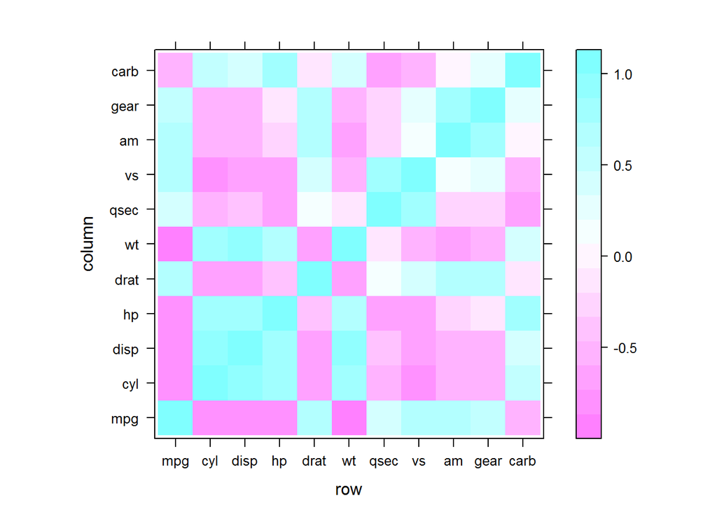

```r
levelplot(z)
```

A model with only transmission:

```r
# only am
data = mtcars
data$am = as.factor(data$am)
model2 = lm(mpg ~ am, data = data)

# get results
summary(model2)
```

```
##
## Call:
## lm(formula = mpg ~ am, data = data)
##
## Residuals:
##     Min      1Q  Median      3Q     Max
## -9.3923 -3.0923 -0.2974  3.2439  9.5077
##
## Coefficients:
##             Estimate Std. Error t value Pr(>|t|)
## (Intercept)   17.147      1.125  15.247 1.13e-15 ***
## am1            7.245      1.764   4.106 0.000285 ***
## ---
## Signif. codes:  0 '***' 0.001 '**' 0.01 '*' 0.05 '.' 0.1 ' ' 1
##
## Residual standard error: 4.902 on 30 degrees of freedom
## Multiple R-squared:  0.3598, Adjusted R-squared:  0.3385
## F-statistic: 16.86 on 1 and 30 DF,  p-value: 0.000285
```

Observations:

- the intercept is 17.15: exactly the same mean of mpg for cars with automatic transmission
- the coefficient of am is 7.24: exactly the difference of mpg means for cars with manual / automatic transmission
- the sum of intercept and am coefficient gives the mpg unconditional mean for cars with manual transmission

### 3.2 Best Fit Procedure

```r
#### model selection using leaps ####
library(leaps)
data = mtcars
data$log_mpg = log(data$mpg) # add log of y

#### method 1. best fit ####
regfit.full = regsubsets(log_mpg ~. , data = data, nvmax = 10)
reg.summary = summary(regfit.full)
reg.summary
```

```
## Subset selection object
## Call: regsubsets.formula(log_mpg ~ ., data = data, nvmax = 10)
## 11 Variables  (and intercept)
##      Forced in Forced out
## mpg      FALSE      FALSE
## cyl      FALSE      FALSE
## disp     FALSE      FALSE
## hp       FALSE      FALSE
## drat     FALSE      FALSE
## wt       FALSE      FALSE
## qsec     FALSE      FALSE
## vs       FALSE      FALSE
## am       FALSE      FALSE
## gear     FALSE      FALSE
## carb     FALSE      FALSE
## 1 subsets of each size up to 10
## Selection Algorithm: exhaustive
##           mpg cyl disp hp  drat wt  qsec vs  am  gear carb
## 1  ( 1 )  "*" " " " "  " " " "  " " " "  " " " " " "  " "
## 2  ( 1 )  "*" " " "*"  " " " "  " " " "  " " " " " "  " "
## 3  ( 1 )  "*" " " "*"  " " " "  "*" " "  " " " " " "  " "
## 4  ( 1 )  "*" " " "*"  " " " "  "*" " "  " " "*" " "  " "
## 5  ( 1 )  "*" " " "*"  " " " "  "*" " "  "*" "*" " "  " "
## 6  ( 1 )  "*" "*" "*"  " " " "  " " " "  " " "*" "*"  "*"
## 7  ( 1 )  "*" "*" "*"  " " " "  "*" " "  " " "*" "*"  "*"
## 8  ( 1 )  "*" "*" "*"  " " " "  "*" " "  "*" "*" "*"  "*"
## 9  ( 1 )  "*" "*" "*"  " " "*"  "*" " "  "*" "*" "*"  "*"
## 10  ( 1 ) "*" "*" "*"  " " "*"  "*" "*"  "*" "*" "*"  "*"
```

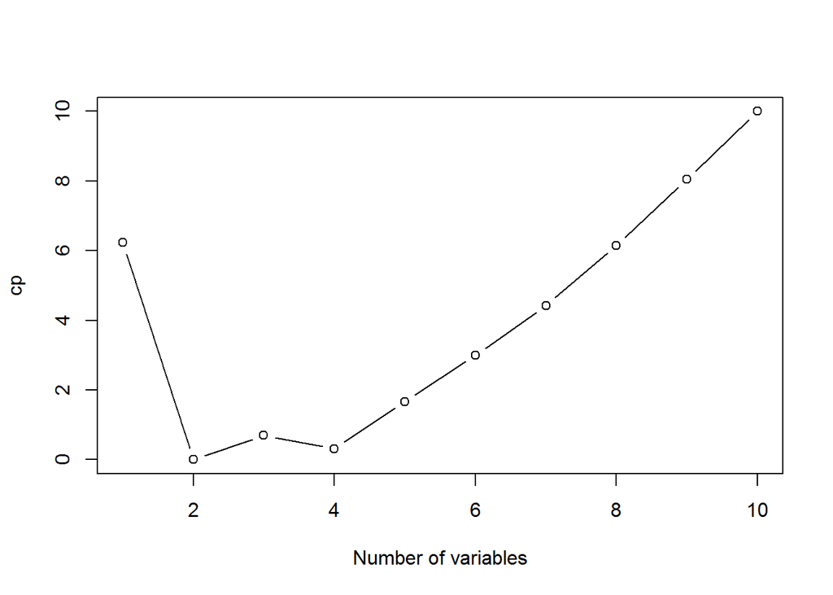

```r
# how I select the optimal number of variables?
plot(reg.summary$cp, xlab = "Number of variables", ylab = "cp", type = "b")
```

### 3.3 Forward Stepwise Procedure

```r
regfit.fwd = regsubsets(log_mpg ~ ., data = data, nvmax = 10, method = "forward")
summary(regfit.fwd)
```

```
## Subset selection object
## Call: regsubsets.formula(log_mpg ~ ., data = data, nvmax = 10, method = "forward")
## 11 Variables  (and intercept)
##      Forced in Forced out
## mpg      FALSE      FALSE
## cyl      FALSE      FALSE
## disp     FALSE      FALSE
## hp       FALSE      FALSE
## drat     FALSE      FALSE
## wt       FALSE      FALSE
## qsec     FALSE      FALSE
## vs       FALSE      FALSE
## am       FALSE      FALSE
## gear     FALSE      FALSE
## carb     FALSE      FALSE
## 1 subsets of each size up to 10
## Selection Algorithm: forward
##           mpg cyl disp hp  drat wt  qsec vs  am  gear carb
## 1  ( 1 )  "*" " " " "  " " " "  " " " "  " " " " " "  " "
## 2  ( 1 )  "*" " " "*"  " " " "  " " " "  " " " " " "  " "
## 3  ( 1 )  "*" " " "*"  " " " "  "*" " "  " " " " " "  " "
## 4  ( 1 )  "*" " " "*"  " " " "  "*" " "  " " "*" " "  " "
## 5  ( 1 )  "*" " " "*"  " " " "  "*" " "  "*" "*" " "  " "
## 6  ( 1 )  "*" " " "*"  " " " "  "*" " "  "*" "*" "*"  " "
## 7  ( 1 )  "*" " " "*"  " " " "  "*" " "  "*" "*" "*"  "*"
## 8  ( 1 )  "*" "*" "*"  " " " "  "*" " "  "*" "*" "*"  "*"
## 9  ( 1 )  "*" "*" "*"  " " "*"  "*" " "  "*" "*" "*"  "*"
## 10  ( 1 ) "*" "*" "*"  " " "*"  "*" "*"  "*" "*" "*"  "*"
```

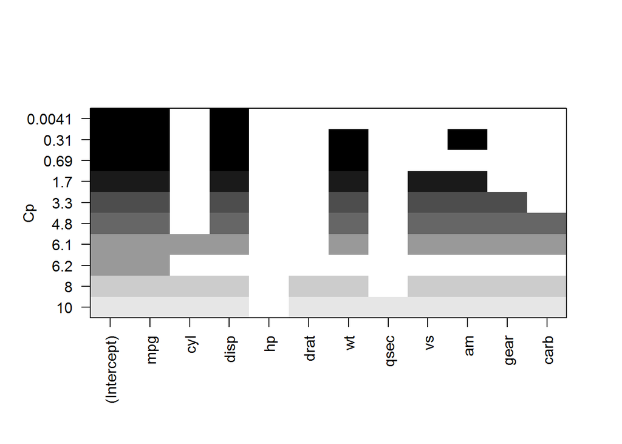

```r
plot(regfit.fwd, scale = "Cp")
```

### *** Appendix ****

A model including all regressors.

```r
#### lm with all variables / no split ####
# prepare data
data = mtcars
data$am = as.factor(data$am)

model1 = lm(mpg ~ ., data = data)

# get results
summary(model1)
```

```
##
## Call:
## lm(formula = mpg ~ ., data = data)
##
## Residuals:
##     Min      1Q  Median      3Q     Max
## -3.4506 -1.6044 -0.1196  1.2193  4.6271
##
## Coefficients:
##             Estimate Std. Error t value Pr(>|t|)
## (Intercept) 12.30337   18.71788   0.657   0.5181
## cyl         -0.11144    1.04502  -0.107   0.9161
## disp         0.01334    0.01786   0.747   0.4635
## hp          -0.02148    0.02177  -0.987   0.3350
## drat         0.78711    1.63537   0.481   0.6353
## wt          -3.71530    1.89441  -1.961   0.0633 .
## qsec         0.82104    0.73084   1.123   0.2739
## vs           0.31776    2.10451   0.151   0.8814
## am1          2.52023    2.05665   1.225   0.2340
## gear         0.65541    1.49326   0.439   0.6652
## carb        -0.19942    0.82875  -0.241   0.8122
## ---
## Signif. codes:  0 '***' 0.001 '**' 0.01 '*' 0.05 '.' 0.1 ' ' 1
##
## Residual standard error: 2.65 on 21 degrees of freedom
## Multiple R-squared:  0.869,  Adjusted R-squared:  0.8066
## F-statistic: 13.93 on 10 and 21 DF,  p-value: 3.793e-07
```

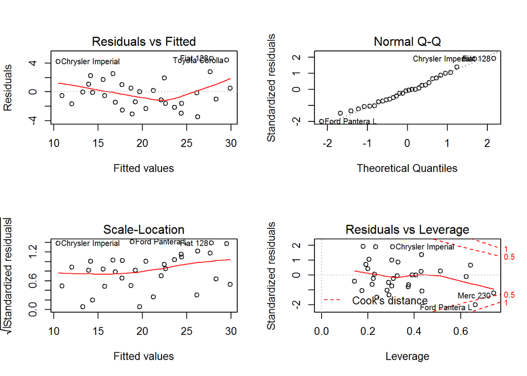

```r
# plot residual analysis
par(mfrow = c(2, 2))
plot(model1)
```

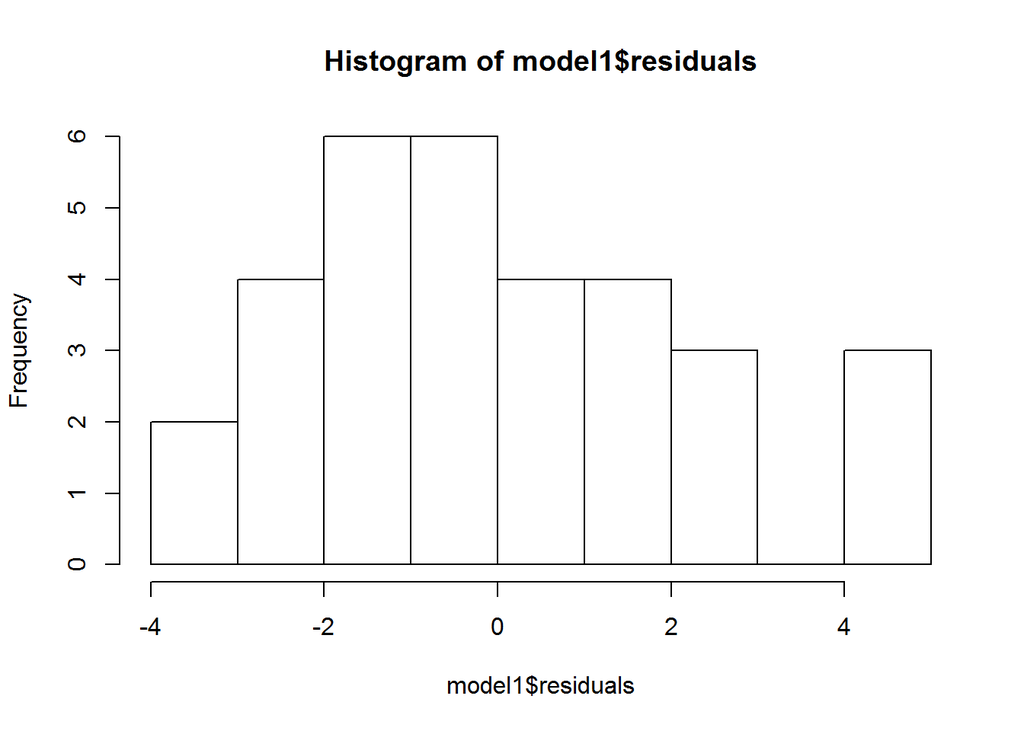

```r
# plot hist
par(mfrow = c(1, 1))
hist(model1$residuals)
```

```r
# normality test on residuals
shapiro.test(model1$residuals)
```

```
##
##  Shapiro-Wilk normality test
##
## data:  model1$residuals
## W = 0.9569, p-value = 0.2261
```